# Rintrodev

Introduction: R and Jupyter

Welcome to *R*, on HCC/Binder, through Jupyter.

*"R is a free software environment for statistical computing and graphics"*  
[www.r-project.org](https://www.r-project.org/)  
*"The Jupyter Notebook is an open-source web application that allows you to create and share documents that contain live code, equations, visualizations and narrative text"*  
[www.jupyter.org](https://jupyter.org/)

Here, we'll be touching upon some of the fundamentals of programming in the *R* language. Topics to be covered include: functions, structures, packages, manipulation, graphics, saving and loading.

Jupyter Notebook  
Segregated into a kernel (execute code) and dashboard/editor (interface), Jupyter permits mixing real-time coding with interactive rich-text ouputs in self-contained *.ipynb(JSON)* files (local or remote).  
Kernels include **Julia**, **Python**, **R**, **MATLAB/Octave**, etc.  
Interact with input cells (code, markdown, etc) that exhibit an order and mode - insert, edit, run.

`$ jupyter notebook`

R  
Starting *R* loads an interpreter and creates a workspace/environment to store values and perform commands - 'session'.  
Interact with terminal directly or indirectly through scripts (*.R* extension).

```r
#R - load & open (terminal)
#module load R.3.4
#R
```

```r
getwd()
```

[output not shown]

```r
list.files()
```

[output not shown]

Calculations  
Mathematical calculations - elements & arrays (/vectors).  
Example operators: `+`, `-`, `*`, `/`, `^`.

```r
(20+20)/5
```

8

```r
c(1,2,3,4) * c(1,2,3,4)
```

1. 1

2. 4

3. 9

4. 16

```r
81^(1/2)
```

9

```r
sqrt(81); #built-in code (base functions)
```

9

Functions  
Perform procedures - Input to Output with options/arguments (*round brackets*).  
Combining elements `c()` is one of the simplest 'base' functions.  
With no defined arguments, functions when called will resort to default values found in documentation (? / help).

```r
#nested example (runif = generate random number)
sort( runif(10, min=0, max=1) , decreasing=FALSE, index.return=FALSE )
```

1. 0.0285129863768816

2. 0.0938390463124961

3. 0.108732287306339

4. 0.167099769227207

5. 0.233837811974809

6. 0.298011876409873

7. 0.326980934944004

8. 0.338217505021021

9. 0.409503625240177

10. 0.826538030290976

```r
#check documentation (usage, arguments, details, examples, etc)
?runif
```

```r
calculate_SE <- function(x){
    #define function to calculate standard error ({body - local env})
    return( sqrt(var(x) / length(x)) )
}

calculate_SE( c(10.4, 5.6, 3.1, 6.4, 21.7) ); #run function
```

3.28185922915655

```r
x <- c(10.4, 5.6, 3.1, 6.4, 21.7);
#x = c(10.4, 5.6, 3.1, 6.4, 21.7);

typeof(x)
x
```

'double'

1. 10.4

2. 5.6

3. 3.1

4. 6.4

5. 21.7

```r
y <- c("test", "control", "control", "control", "test");
#y = c("test", "control", "control", "control", "test");

typeof(y)
y
```

'character'

1. 'test'

2. 'control'

3. 'control'

4. 'control'

5. 'test'

Structures  
While vectors are the most important type of object/structure/variable in *R*, others exist each with intrinsic attributes (mode and length). Conversion between types is relatively intuitive - `as.character`, `as.numeric`, `as.data.frame`.  
Examples: matrices, lists, dataframes.

```r
#matrices - visualize toy example
set.seed(5); #define seed to reproduce random results
X = matrix( runif(20, min=0, max=10) , nrow=4, ncol=5, byrow=FALSE);

dim(X)
X
```

1. 4

2. 5

| 2.002145 | 1.046501 | 9.565001 | 3.184040 | 3.875257 |
| --- | --- | --- | --- | --- |
| 6.852186 | 7.010575 | 1.104530 | 5.591728 | 8.878698 |
| 9.168758 | 5.279600 | 2.732849 | 2.625931 | 5.549226 |
| 2.843995 | 8.079352 | 4.905132 | 2.018752 | 8.421794 |

Indexing  
Access parts of a dataset, rows then columns (*square brackets*), starting with 1, can be coded multiple ways.  
Wildcard `:` generates a regular sequence from start to stop (by 1).

```r
X[2, 4]
```

5.59172826586291

```r
t(X)[2, 4]; #transpose (rows to columns, columns to rows)
```

8.07935200864449

```r
X[c(2,4), 4] = c(0,10); #replace elements
X
```

| 2.002145 | 1.046501 | 9.565001 | 3.184040 | 3.875257 |
| --- | --- | --- | --- | --- |
| 6.852186 | 7.010575 | 1.104530 | 0.000000 | 8.878698 |
| 9.168758 | 5.279600 | 2.732849 | 2.625931 | 5.549226 |
| 2.843995 | 8.079352 | 4.905132 | 10.000000 | 8.421794 |

```r
X[1:3, 2:3]

cbind(X[1:3, 2], X[1:3, 3]); #concatenate columns

#rbind(X[1, 2:3], X[2, 2:3], X[3, 2:3]); #concatenate rows
```

| 1.046501 | 9.565001 |
| --- | --- |
| 7.010575 | 1.104530 |
| 5.279600 | 2.732849 |

| 1.046501 | 9.565001 |
| --- | --- |
| 7.010575 | 1.104530 |
| 5.279600 | 2.732849 |

Conditions  
Checks that control the flow of actions/execution (if / else).  
Comparsion: lesser than (`<`), greater than (`>`), equal (`==`), different (`!=`).  
Logical/Boolean: AND (`&`) if both *true*, OR (`|`) if either *true*, NOT (`!`) converts *true* to *false*.

```r
X[X > 5]; #output - free from dimensions (byrow=FALSE)
X
```

1. 6.85218595666811

2. 9.1687577450648

3. 7.01057459227741

4. 5.27959984261543

5. 8.07935200864449

6. 9.565001251176

7. 10

8. 8.87869771569967

9. 5.5492255394347

10. 8.42179385246709

| 2.002145 | 1.046501 | 9.565001 | 3.184040 | 3.875257 |
| --- | --- | --- | --- | --- |
| 6.852186 | 7.010575 | 1.104530 | 0.000000 | 8.878698 |
| 9.168758 | 5.279600 | 2.732849 | 2.625931 | 5.549226 |
| 2.843995 | 8.079352 | 4.905132 | 10.000000 | 8.421794 |

```r
X[X >= 6 & X <= 7]; #across whole matrix
X[1, X[1, ] >= 6 & X[1, ] <= 7]; #only first row
```

6.85218595666811

```r
if (dim(X)[1] != 4) {
    print("check - dimensions don't match"); #first check cond.1, TRUE do something
} else if (dim(X)[2] != 5) {
    print("check - dimensions don't match"); #FALSE then try cond.2, TRUE now do something different
} else {
    print("good - dimensions match"); #FALSE again, do something else
}
```

```
[1] "good - dimensions match"
```

```r
y[y == "test"]
```

1. 'test'

2. 'test'

Check-In Point I  
1) EXERCISE - create new variable, **randlett**, of 2000 randomly sampled ?LETTERS (hint), and count occurrences (a-z).  
2) EXERCISE - define new function, **roundndivide**, to take two numeric/double inputs (x1 and x2), rounds to nearest integers, divides integers, and returns logical output (TRUE/FALSE) if absolute of result is greater than 1.

```r
# TO CONTINUE CLICK 'TOGGLE' AND MAKE ME DISAPPEAR #
```

[ TOGGLE ]

```r
randlett <- table( letters[sample(1:length(letters), 2000, replace=TRUE)] );
print(randlett)
```

```
 a  b  c  d  e  f  g  h  i  j  k  l  m  n  o  p  q  r  s  t  u  v  w  x  y  z
71 73 77 81 83 77 83 71 80 83 88 65 78 69 67 72 91 67 76 81 75 71 77 94 72 78
```

```r
roundndivide <- function(x1, x2){ if ( abs((round(x1, digits=0)/round(x2, digits=0))) > 1){ TRUE }else{ FALSE } }
print( roundndivide(11.25, 22.25) )
```

```
[1] FALSE
```

Iterations  
Scalar loops, element by element, can be used to repeat procedures (for / while).  
Vectorization, all elements at once, however is faster and scalable - `apply` (array), `lapply` (list), `sapply` (vector) - reducing redundancies/overhead, using Fortan / C / C++ routines, and so on.

```r
#initiate variable of NA (missing values) to fill during loop (preallocate - growing objects inefficient)
colMean = rep(NA, times=dim(X)[2]);

for (i in 1:dim(X)[2]){
    #variable i in sequence start:end
    print(i)
    colMean[i] = mean(X[ ,i])
    #break;#next
}
#colMean
```

```
[1] 1
[1] 2
[1] 3
[1] 4
[1] 5
```

```r
colMean = apply(X, 2, mean); #column by column
colMean
```

1. 5.21677070006263

2. 5.35400693072006

3. 4.5768782380037

4. 3.95249289344065

5. 6.68124364456162

```r
#colMeans(X) #built-in
```

```r
rowSE = apply(X, 1, calculate_SE); #row by row
rowSE
```

1. 1.48902280369221

2. 1.76671496729455

3. 1.19392504007638

4. 1.2987481128253

Packages  
Executable codes/functions developed by the community are organised and shared online in resposities - these can be retrieved/downloaded (source (compile) vs bundled (compressed) vs binary (pre-built)), structured into directories (libraries) and loaded into memory to use. Packages will often require other packages - dependencies.  
Repositories: **CRAN** (official network), **Bioconductor** (bioinformatic specific), **GitHub**.  
Packages: `Tidyverse`, `Shiny`, `dada2`, `phyloseq`, `MetaboAnalystR`, `lme4`.

```r
#lapply(.libPaths(), dir)
lapply(.libPaths(), list.files) #print available/downloaded packages
```

1. 1. 'askpass'

   2. 'assertthat'

   3. 'backports'

   4. 'base'

   5. 'base64enc'

   6. 'BH'

   7. 'boot'

   8. 'broom'

   9. 'callr'

   10. 'caret'

   11. 'cellranger'

   12. 'class'

   13. 'cli'

   14. 'clipr'

   15. 'cluster'

   16. 'codetools'

   17. 'colorspace'

   18. 'compiler'

   19. 'crayon'

   20. 'crosstalk'

   21. 'curl'

   22. 'data.table'

   23. 'datasets'

   24. 'DBI'

   25. 'dbplyr'

   26. 'dichromat'

   27. 'digest'

   28. 'dplyr'

   29. 'e1071'

   30. 'ellipsis'

   31. 'evaluate'

   32. 'fansi'

   33. 'forcats'

   34. 'foreach'

   35. 'foreign'

   36. 'formatR'

   37. 'fs'

   38. 'generics'

   39. 'ggplot2'

   40. 'glmnet'

   41. 'glue'

   42. 'gower'

   43. 'graphics'

   44. 'grDevices'

   45. 'grid'

   46. 'gtable'

   47. 'haven'

   48. 'hexbin'

   49. 'highr'

   50. 'hms'

   51. 'htmltools'

   52. 'htmlwidgets'

   53. 'httpuv'

   54. 'httr'

   55. 'ipred'

   56. 'IRdisplay'

   57. 'IRkernel'

   58. 'iterators'

   59. 'jsonlite'

   60. 'KernSmooth'

   61. 'knitr'

   62. 'labeling'

   63. 'later'

   64. 'lattice'

   65. 'lava'

   66. 'lazyeval'

   67. 'lubridate'

   68. 'magrittr'

   69. 'maps'

   70. 'markdown'

   71. 'MASS'

   72. 'Matrix'

   73. 'methods'

   74. 'mgcv'

   75. 'mime'

   76. 'ModelMetrics'

   77. 'modelr'

   78. 'munsell'

   79. 'nlme'

   80. 'nnet'

   81. 'numDeriv'

   82. 'openssl'

   83. 'parallel'

   84. 'pbdZMQ'

   85. 'pillar'

   86. 'pkgconfig'

   87. 'plogr'

   88. 'plotly'

   89. 'pls'

   90. 'plyr'

   91. 'png'

   92. 'prettyunits'

   93. 'processx'

   94. 'prodlim'

   95. 'progress'

   96. 'promises'

   97. 'ps'

   98. 'purrr'

   99. 'quantmod'

   100. 'R6'

   101. 'randomForest'

   102. 'rbokeh'

   103. 'RColorBrewer'

   104. 'Rcpp'

   105. 'RcppRoll'

   106. 'readr'

   107. 'readxl'

   108. 'recipes'

   109. 'rematch'

   110. 'repr'

   111. 'reprex'

   112. 'reshape2'

   113. 'rlang'

   114. 'rmarkdown'

   115. 'rpart'

   116. 'rstudioapi'

   117. 'rvest'

   118. 'scales'

   119. 'selectr'

   120. 'shiny'

   121. 'sourcetools'

   122. 'spatial'

   123. 'splines'

   124. 'SQUAREM'

   125. 'stats'

   126. 'stats4'

   127. 'stringi'

   128. 'stringr'

   129. 'survival'

   130. 'sys'

   131. 'tcltk'

   132. 'tibble'

   133. 'tidyr'

   134. 'tidyselect'

   135. 'tidyverse'

   136. 'timeDate'

   137. 'tinytex'

   138. 'tools'

   139. 'translations'

   140. 'TTR'

   141. 'utf8'

   142. 'utils'

   143. 'uuid'

   144. 'viridisLite'

   145. 'whisker'

   146. 'withr'

   147. 'xfun'

   148. 'xml2'

   149. 'xtable'

   150. 'xts'

   151. 'yaml'

   152. 'zoo'

```r
#install.packages('ggplot2')
library(ggplot2) #load into session
#?detach();#?remove.packages()
```

```r
#source("https://bioconductor.org/biocLite.R");biocLite()
#install.packages('devtools');devtools::install_github()
```

```r
#packages can contain data also
data(package = "ggplot2")
```

```r
data("midwest", package = "ggplot2"); #call dataset (midwest demographics) into memory/env

class(midwest)
dim(midwest)
```

1. 'tbl_df'

2. 'tbl'

3. 'data.frame'

1. 437

2. 28

**Dataframes**  
A special list of vectors of equal length that suggests an implicit relationship between elements.  
Without such restrictions, variable type would default to a basic list.

```r
head(midwest, n=2)
```

| PID | county | state | area | poptotal | popdensity | popwhite | popblack | popamerindian | popasian | ... | percollege | percprof | poppovertyknown | percpovertyknown | percbelowpoverty | percchildbelowpovert | percadultpoverty | percelderlypoverty | inmetro | category |
| --- | --- | --- | --- | --- | --- | --- | --- | --- | --- | --- | --- | --- | --- | --- | --- | --- | --- | --- | --- | --- |
| 561 | ADAMS | IL | 0.052 | 66090 | 1270.962 | 63917 | 1702 | 98 | 249 | ... | 19.63139 | 4.355859 | 63628 | 96.27478 | 13.15144 | 18.01172 | 11.00978 | 12.44381 | 0 | AAR |
| 562 | ALEXANDER | IL | 0.014 | 10626 | 759.000 | 7054 | 3496 | 19 | 48 | ... | 11.24331 | 2.870315 | 10529 | 99.08714 | 32.24428 | 45.82651 | 27.38565 | 25.22898 | 0 | LHR |

```r
print(colnames(midwest))
#rownames(midwest)
```

```
 [1] "PID"                  "county"               "state"
 [4] "area"                 "poptotal"             "popdensity"
 [7] "popwhite"             "popblack"             "popamerindian"
[10] "popasian"             "popother"             "percwhite"
[13] "percblack"            "percamerindan"        "percasian"
[16] "percother"            "popadults"            "perchsd"
[19] "percollege"           "percprof"             "poppovertyknown"
[22] "percpovertyknown"     "percbelowpoverty"     "percchildbelowpovert"
[25] "percadultpoverty"     "percelderlypoverty"   "inmetro"
[28] "category"
```

```r
#get unique 'states' (with example indexing)
unique(midwest$state)
unique(midwest[ ,"state"])
unique(midwest[ ,3])
```

1. 'IL'

2. 'IN'

3. 'MI'

4. 'OH'

5. 'WI'

| state |
| --- |
| IL |
| IN |
| MI |
| OH |
| WI |

| state |
| --- |
| IL |
| IN |
| MI |
| OH |
| WI |

Manipulation  
Packages `dplyr` and `tidyr` are popular methods to wield (*select, exclude, add*) dataframes - rows/columns.  
Base functions exist also and again can be coded multiple ways.

```r
#base method (logical TRUE/FALSE)
datOH = midwest[midwest$state=="OH", ];datOH[1:2,]
#datOHc = midwest[midwest$state=="OH", 2];datOHc[1:2,]
```

| PID | county | state | area | poptotal | popdensity | popwhite | popblack | popamerindian | popasian | ... | percollege | percprof | poppovertyknown | percpovertyknown | percbelowpoverty | percchildbelowpovert | percadultpoverty | percelderlypoverty | inmetro | category |
| --- | --- | --- | --- | --- | --- | --- | --- | --- | --- | --- | --- | --- | --- | --- | --- | --- | --- | --- | --- | --- |
| 2009 | ADAMS | OH | 0.035 | 25371 | 724.8857 | 25212 | 47 | 67 | 30 | ... | 8.74173 | 2.158135 | 25028 | 98.64806 | 28.52805 | 35.02468 | 25.75226 | 26.18006 | 0 | LHR |
| 2010 | ALLEN | OH | 0.024 | 109755 | 4573.1250 | 96177 | 12313 | 202 | 572 | ... | 17.36606 | 3.479308 | 104543 | 95.25124 | 12.66656 | 17.85799 | 10.56792 | 10.74442 | 1 | AAU |

```r
#base method (indexed INTEGER)
indexOH = which(midwest$state=="OH");indexOH[1:10]
#datOH = midwest[indexOH, ];head(datOH)
```

1. 278

2. 279

3. 280

4. 281

5. 282

6. 283

7. 284

8. 285

9. 286

10. 287

```r
#datminusOH = midwest[-indexOH, ]; #exclude (-)
```

```r
#install.packages('dplyr')
library(dplyr)
```

```r
#dplyr uses '%>%' as a pipe - pass left side as first argument of right side
#unique(midwest$state)
distinct(midwest, state)
midwest %>% distinct(state)
```

| state |
| --- |
| IL |
| IN |
| MI |
| OH |
| WI |

| state |
| --- |
| IL |
| IN |
| MI |
| OH |
| WI |

```r
#dplyr filters rows & selects columns (%in% = belong to/member of | INVERSE with !%in%)
datsubAAR = midwest %>%
    #filter(category=="AAR") %>%
    filter(category %in% "AAR" & state %in% "IL") %>% #multiple cond. (category & state)
    #arrange(desc(popdensity)) %>%
    select(county, state, popdensity, popwhite, popblack, popamerindian, popasian, category)

datsubAAR[1:2,]
```

| county | state | popdensity | popwhite | popblack | popamerindian | popasian | category |
| --- | --- | --- | --- | --- | --- | --- | --- |
| ADAMS | IL | 1270.9615 | 63917 | 1702 | 98 | 249 | AAR |
| BOND | IL | 681.4091 | 14477 | 429 | 35 | 16 | AAR |

```r
#add new columns (using current data or not)
datsubAAR = datsubAAR %>%
    mutate(poptotalrecal = popwhite + popblack + popamerindian + popasian,
           fakegroups = rep( c("North","South","Central"), times=17) )
    #transmute(poptotalrecal = popwhite + popblack + popamerindian + popasian)

datsubAAR[1:2,]
```

| county | state | popdensity | popwhite | popblack | popamerindian | popasian | category | poptotalrecal | fakegroups |
| --- | --- | --- | --- | --- | --- | --- | --- | --- | --- |
| ADAMS | IL | 1270.9615 | 63917 | 1702 | 98 | 249 | AAR | 65966 | North |
| BOND | IL | 681.4091 | 14477 | 429 | 35 | 16 | AAR | 14957 | South |

```r
#dplyr has helper functions for ease/speed
datsubAAR = datsubAAR %>%
    #select(-starts_with("poptotal")) #exclude (-)
    #select(-ends_with("recal")) #exclude (-)
    select(-contains("recal")) #exclude (-)

datsubAAR[1:2,]
```

| county | state | popdensity | popwhite | popblack | popamerindian | popasian | category | fakegroups |
| --- | --- | --- | --- | --- | --- | --- | --- | --- |
| ADAMS | IL | 1270.9615 | 63917 | 1702 | 98 | 249 | AAR | North |
| BOND | IL | 681.4091 | 14477 | 429 | 35 | 16 | AAR | South |

```r
#summarise data (statistics - with or without groups)
datsubAAR %>%
    summarise(mean(popdensity), sd(popdensity), n())

#?group_by(); #operations according groups
```

| mean(popdensity) | sd(popdensity) | n() |
| --- | --- | --- |
| 797.576 | 428.5143 | 51 |

```r
#install.packages('tidyr')
library(tidyr)
```

```r
#dataframes - visualize toy example
newdf = data.frame(
        sampleID = c("exp1","exp2","exp3","exp4"),
        groupID = c("control","control","test","test"),
        tp1 = c(10, 12, 11, 11), #measurement @ timepoint-1
        tp2 = c(20, 20, 38, 39), #measurement @ timepoint-2
        tp3 = c(20, 20, 50, 52) #measurement @ timepoint-3
)

newdf
```

| sampleID | groupID | tp1 | tp2 | tp3 |
| --- | --- | --- | --- | --- |
| exp1 | control | 10 | 20 | 20 |
| exp2 | control | 12 | 20 | 20 |
| exp3 | test | 11 | 38 | 50 |
| exp4 | test | 11 | 39 | 52 |

```r
#reshape/format - wide to long (ggplot2 likes)
newdflong <- gather(newdf, tPoint, tMeasure, tp1:tp3, factor_key=TRUE)
head(newdflong, n=8)
```

| sampleID | groupID | tPoint | tMeasure |
| --- | --- | --- | --- |
| exp1 | control | tp1 | 10 |
| exp2 | control | tp1 | 12 |
| exp3 | test | tp1 | 11 |
| exp4 | test | tp1 | 11 |
| exp1 | control | tp2 | 20 |
| exp2 | control | tp2 | 20 |
| exp3 | test | tp2 | 38 |
| exp4 | test | tp2 | 39 |

```r
#?spread(); #reshape/format - long to wide
```

Check-In Point II  
1) EXERCISE - print group statistics - *min, median, max* - for '**percadultpoverty**' and '**percelderlypoverty**', using '**inmetro**', in dataframe **midwest** (with *dplyr*).  
2) EXERCISE - reshape dataframe **newdflong** from long to wide as new dataframe **newdfwide** (with *tidyr*).

```r
# TO CONTINUE CLICK 'TOGGLE' AND MAKE ME DISAPPEAR #
```

[ TOGGLE ]

```r
stats <- midwest %>%
    group_by(inmetro) %>%
    select(percadultpoverty, percelderlypoverty, inmetro) %>%
    summarise_all(list(min=min, median=median, max=max))
print(as.data.frame(stats))
```

```
  inmetro percadultpoverty_min percelderlypoverty_min percadultpoverty_median
1       0             4.238700               6.723426               10.926610
2       1             1.938504               3.547067                8.647925
  percelderlypoverty_median percadultpoverty_max percelderlypoverty_max
1                 12.293026             43.31246               31.16197
2                  9.034515             22.99900               16.38753
```

```r
newdfwide <- spread(newdflong, tPoint, tMeasure)
newdfwide
```

| sampleID | groupID | tp1 | tp2 | tp3 |
| --- | --- | --- | --- | --- |
| exp1 | control | 10 | 20 | 20 |
| exp2 | control | 12 | 20 | 20 |
| exp3 | test | 11 | 38 | 50 |
| exp4 | test | 11 | 39 | 52 |

Graphics  
For visualizations package `ggplot2` is preferred over base functions (`plot()`, `lines()`, `barplot()`).  
Mapping data, which can come from multiple sources (dataframes), to graphic attributes (`x`, `y`, `color`, `fill`, `group`) is done through aesthetics `(aes)`.  
Layers (geoms, stats, position, annotation), scales, facets, coordinate systems, themes can all then be added with `+`.  
Example geoms: `geom_point`, `geom_line`, `geom_bar`, `geom_boxplot`, `geom_polygon`, `geom_path`.

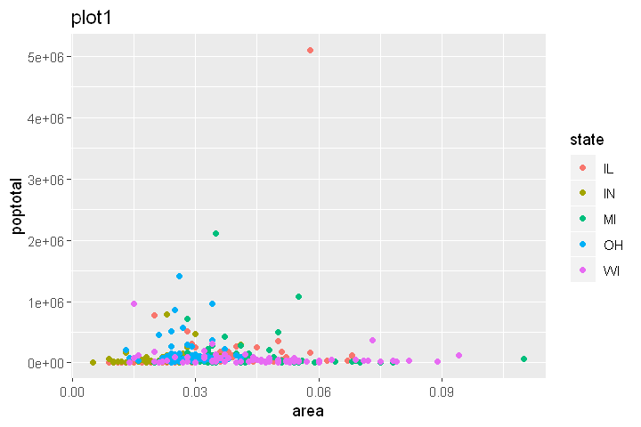

```r
plt1 = ggplot( data=midwest, aes(x=area, y=poptotal, color=state) ) +
    #scatter geometric object (points = observation/county)
    geom_point() + ggtitle("plot1")

options(repr.plot.width=6, repr.plot.height=4) # output size (Jupyter)
plt1
```

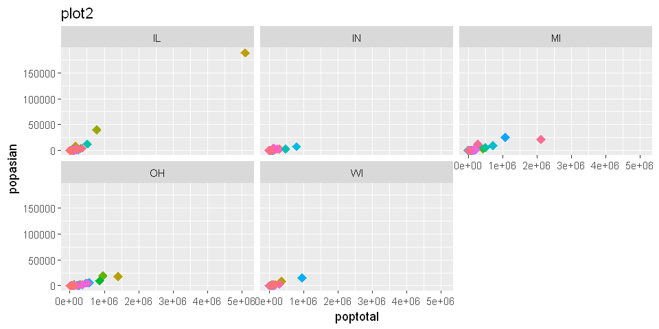

```r
plt2 = ggplot( data=midwest, aes(x=poptotal, y=popasian) ) +
    #scatter geometric object (points = observation/county)
    geom_point( aes(color=county), shape=18, size=3.5, show.legend=FALSE ) + ggtitle("plot2") +
    #subplot dataset by column/variable (state)
        facet_wrap( ~state, scales="fixed", nrow=2 )
        #facet_wrap( ~state, scales="free", nrow=2 )

options(repr.plot.width=8, repr.plot.height=4) # output size (Jupyter)
plt2
```

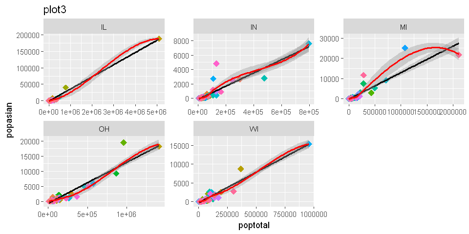

```r
plt3 = plt2 + ggtitle("plot3") +
    facet_wrap( ~state, scales="free", nrow=2 ) +
    #statistical transformation (here groups = facets / local vs global)
        stat_smooth( method = "lm", formula=y~x, size=1, se=T, color="black" ) +
        stat_smooth( aes(group=state), method = "loess", formula=y~x, size=1, se=T, color="red" )

options(repr.plot.width=8, repr.plot.height=4) # output size (Jupyter)
plt3
```

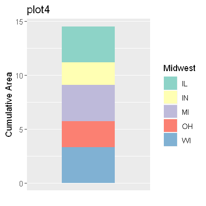

```r
plt4 = ggplot( data=midwest, aes(x=1, y=area, fill=state) ) + ggtitle("plot4") +
    #bar geometric object (stat="identity" - raw data)
    geom_bar( stat="identity", position="stack" ) +
    labs( x="", y="Cumulative Area", fill="Midwest" ) +
    #scale discrete (not continuous) for fill (not color)
        scale_fill_brewer( palette="Set3" ) +
        #scale_fill_manual(values=c("#FFCCFF","#CC99FF","#9933FF", "#330099", "#000033")) +
    scale_x_discrete( breaks="", labels="" )

options(repr.plot.width=3.5, repr.plot.height=3.5) # output size (Jupyter)
plt4
```

```r
#print figures to file (pdf / png / svg / etc)
pdf("Figures.pdf", width=40, height=20)
print(plt1)
print(plt2)
print(plt3)
print(plt4)
dev.off()

#?ggsave();#built-in save function
```

Check-In Point III  
1) EXERCISE - recreate **plt1** so that size of points proportional to '**percbelowpoverty**', y-axis log10 transformed, axis text italics size 10, background black and major white grid lines.  
2)EXERCISE - recreate **plt4** so that bars are now plotted horizontally per '**state**' (unstacked/unfaceted).

```r
# TO CONTINUE CLICK 'TOGGLE' AND MAKE ME DISAPPEAR #
```

[ TOGGLE ]

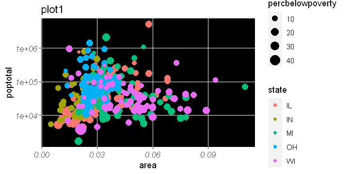

```r
plt1 <- ggplot( data=midwest, aes(x=area, y=poptotal, color=state) ) +
    geom_point(aes(size=percbelowpoverty)) +
    scale_y_log10() +
    ggtitle("plot1") +
    theme(axis.text=element_text(size=10, face="italic"),
          panel.background=element_rect(fill="black"),
          panel.grid.major=element_line(colour="white"),
          panel.grid.minor=element_blank())

options(repr.plot.width=6, repr.plot.height=3) # output size (Jupyter)
plt1
```

Check-In Point III  
1) EXERCISE - recreate **plt1** so that size of points proportional to '**percbelowpoverty**', y-axis log10 transformed, axis text italics size 10, background black and major white grid lines.  
2)EXERCISE - recreate **plt4** so that bars are now plotted horizontally per '**state**' (unstacked/unfaceted).

```r
# TO CONTINUE CLICK 'TOGGLE' AND MAKE ME DISAPPEAR #
```

[ TOGGLE ]

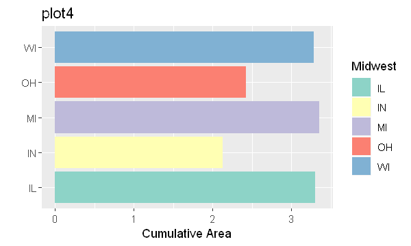

```r
plt4 <- ggplot( data=midwest, aes(x=state, y=area, fill=state) ) +
    ggtitle("plot4") +
    geom_bar( stat="identity", position="stack" ) +
    coord_flip() +
    labs( x="", y="Cumulative Area", fill="Midwest" ) +
    scale_fill_brewer( palette="Set3" )

options(repr.plot.width=5, repr.plot.height=3) # output size (Jupyter)
plt4
```

Saving / Writing  
Workspace objects can be saved as *.Rdata/.Rda* files for logged records or future use.  
Results (data, figures, apps) can be outputted as other files also.

```r
ls() #print env objects
```

1. 'calculate_SE'

2. 'colMean'

3. 'datOH'

4. 'datsubAAR'

5. 'i'

6. 'indexOH'

7. 'midwest'

8. 'newdf'

9. 'newdflong'

10. 'newdfwide'

11. 'plt1'

12. 'plt2'

13. 'plt3'

14. 'plt4'

15. 'randlett'

16. 'roundndivide'

17. 'rowSE'

18. 'stats'

19. 'x'

20. 'X'

21. 'y'

```r
rm(plt1,plt2,plt3,plt4) #remove env objects
```

```r
ls()
```

1. 'calculate_SE'

2. 'colMean'

3. 'datOH'

4. 'datsubAAR'

5. 'i'

6. 'indexOH'

7. 'midwest'

8. 'newdf'

9. 'newdflong'

10. 'newdfwide'

11. 'randlett'

12. 'roundndivide'

13. 'rowSE'

14. 'stats'

15. 'x'

16. 'X'

17. 'y'

```r
save.image("05_29_2019.RData")
#save(list=c("datOH","datminusOH"), file="05_29_2019.RData")
```

```r
#load("05_29_2019.RData")
```

```r
?write.table
```

```r
write.table(midwest, file="ExampleGGData.csv", sep=",")
#write.table(midwest, file="ExampleGGData.txt", sep="\t")
```

```r
list.files(path=".", pattern=".csv")
```

[output not shown]

```r
#rm(list=ls());cat("\014")
```

Loading / Reading  
Importing data into *R* from files (.csv/.txt) can range in complexity - multiple options/arguments.  
Examples: separator/delimiter (*",", "\t", " "*), header.

```r
df = read.table(file="ExampleGGData.csv", sep=",")
#df = read.table(file="ExampleGGData.txt", sep="\t")
df[1:2,]
```

| PID | county | state | area | poptotal | popdensity | popwhite | popblack | popamerindian | popasian | ... | percollege | percprof | poppovertyknown | percpovertyknown | percbelowpoverty | percchildbelowpovert | percadultpoverty | percelderlypoverty | inmetro | category |
| --- | --- | --- | --- | --- | --- | --- | --- | --- | --- | --- | --- | --- | --- | --- | --- | --- | --- | --- | --- | --- |
| 561 | ADAMS | IL | 0.052 | 66090 | 1270.962 | 63917 | 1702 | 98 | 249 | ... | 19.63139 | 4.355859 | 63628 | 96.27478 | 13.15144 | 18.01172 | 11.00978 | 12.44381 | 0 | AAR |
| 562 | ALEXANDER | IL | 0.014 | 10626 | 759.000 | 7054 | 3496 | 19 | 48 | ... | 11.24331 | 2.870315 | 10529 | 99.08714 | 32.24428 | 45.82651 | 27.38565 | 25.22898 | 0 | LHR |

```r
#?read.csv()
#?read.delim()
```

```r
#https://github.com/fivethirtyeight/data

dfOnline = read.table(file="https://raw.githubusercontent.com/fivethirtyeight/data/master/bachelorette/bachelorette.csv", sep=",", header=TRUE)
dfOnline[1:2,]
```

| SHOW | SEASON | CONTESTANT | ELIMINATION.1 | ELIMINATION.2 | ELIMINATION.3 | ELIMINATION.4 | ELIMINATION.5 | ELIMINATION.6 | ELIMINATION.7 | ... | DATES.1 | DATES.2 | DATES.3 | DATES.4 | DATES.5 | DATES.6 | DATES.7 | DATES.8 | DATES.9 | DATES.10 |
| --- | --- | --- | --- | --- | --- | --- | --- | --- | --- | --- | --- | --- | --- | --- | --- | --- | --- | --- | --- | --- |
| SHOW | SEASON | ID | 1 | 2 | 3 | 4 | 5 | 6 | 7 | ... | 1 | 2 | 3 | 4 | 5 | 6 | 7 | 8 | 9 | 10 |
| Bachelorette | 13 | 13_BRYAN_A | R1 |  |  | R | R |  | R | ... |  |  | D6 | D13 | D1 | D7 | D1 | D1 | D1 | D1 |

```r
#quit()
```

Command Line  
Within a terminal *R* can be interactive (open input) or not/batch (closed execution).

`$ R`  
`$ Rscript Rcode.R`  
`$ R CMD BATCH Rcode.R`

*References*  
Software Carpentry: Our Lessons (https://software-carpentry.org/lessons)  
R Packages: Organize, test, document and share your code (https://r-pkgs.org)  
Tidyverse: R packages for data science (https://www.tidyverse.org)  
RStudio: Cheat Sheets (https://www.rstudio.com/resources/cheatsheets)